# Exploratory data analysis

# News Lenta.ru dataset

### by Glazunov Artem

Works via Google Colab

Let's connect directories and load useful libs.

```python
from google.colab import drive
drive.mount('/content/gdrive',force_remount=True)
```

[output not shown]

```python
cd /content/gdrive/'My Drive'/Colab_Notebooks/project_intern
```

```
/content/gdrive/My Drive/Colab_Notebooks/project_intern
```

```python
import os
import pandas as pd


from matplotlib import pyplot as plt
import seaborn as sns
```

```python
PATH_TO_DATA = 'data'
```

Load our data

```python
data = pd.read_csv(os.path.join(PATH_TO_DATA,'lenta-ru-news.csv'))
data
```

|  | url | title | text | topic | tags | date |
| --- | --- | --- | --- | --- | --- | --- |
| 0 | https://lenta.ru/news/1914/09/16/hungarnn/ | 1914. Русские войска вступили в пределы Венгрии | Бои у Сопоцкина и Друскеник закончились отступ... | Библиотека | Первая мировая | 1914/09/16 |
| 1 | https://lenta.ru/news/1914/09/16/lermontov/ | 1914. Празднование столетия М.Ю. Лермонтова от... | Министерство народного просвещения, в виду про... | Библиотека | Первая мировая | 1914/09/16 |
| 2 | https://lenta.ru/news/1914/09/17/nesteroff/ | 1914. Das ist Nesteroff! | Штабс-капитан П. Н. Нестеров на днях, увидев в... | Библиотека | Первая мировая | 1914/09/17 |
| 3 | https://lenta.ru/news/1914/09/17/bulldogn/ | 1914. Бульдог-гонец под Льежем | Фотограф-корреспондент Daily Mirror рассказыва... | Библиотека | Первая мировая | 1914/09/17 |
| 4 | https://lenta.ru/news/1914/09/18/zver/ | 1914. Под Люблином пойман швабский зверь | Лица, приехавшие в Варшаву из Люблина, передаю... | Библиотека | Первая мировая | 1914/09/18 |
| ... | ... | ... | ... | ... | ... | ... |
| 800970 | https://lenta.ru/news/2019/12/14/shnur/ | Шнуров раскритиковал Гагарину на «Голосе» | Певец Сергей Шнуров раскритиковал свою коллегу... | NaN | ТВ и радио | 2019/12/14 |
| 800971 | https://lenta.ru/news/2019/12/14/dolg/ | В России предложили изменить правила взыскания... | Министерство юстиции России предложило изменит... | NaN | Все | 2019/12/14 |
| 800972 | https://lenta.ru/news/2019/12/14/dark_euro/ | В России назвали «черную дату» для Европы | Испытание США ранее запрещенной Договором о ли... | NaN | Политика | 2019/12/14 |
| 800973 | https://lenta.ru/news/2019/12/14/meteo/ | Россиянам пообещали аномально теплую погоду | В ближайшие дни в европейской части России пог... | NaN | Общество | 2019/12/14 |
| 800974 | https://lenta.ru/news/2019/12/14/olimp/ | В конкурсе прогнозов на АПЛ разыграют 100 тыся... | Ведущие футбольные чемпионаты ушли на зимние к... | NaN | Английский футбол | 2019/12/14 |

800975 rows × 6 columns

Let's look at the first text

```python
tt= data.text[0]
tt
```

```
'Бои у Сопоцкина и Друскеник закончились отступлением германцев. Неприятель, приблизившись с севера к Осовцу начал артиллерийскую борьбу с крепостью. В артиллерийском бою принимают участие тяжелые калибры. С раннего утра 14 сентября огонь достиг значительного напряжения. Попытка германской пехоты пр…
```

We have clean data without html tags and and other artifacts, but it still needs to be preprocessed.

Further, we will check some stats.

```python
data.describe()
```

|  | url | title | text | topic | tags | date |
| --- | --- | --- | --- | --- | --- | --- |
| count | 800975 | 800975 | 800970 | 738973 | 773756 | 800975 |
| unique | 800964 | 797832 | 800037 | 23 | 94 | 7393 |
| top | https://lenta.ru/news/2001/06/28/milosevic/ | В Москве объявлено штормовое предупреждение | РИА "Новости" | Россия | Все | 2019/12/05 |
| freq | 2 | 21 | 291 | 160445 | 453762 | 284 |

```python
data.dtypes
```

```
url      object
title    object
text     object
topic    object
tags     object
date     object
dtype: object
```

We can see that in our dataset we have approximately 23 topics and more then 800000 different texts. In our further analysis we will see other interesting information. Let's look at null map of the dataset.

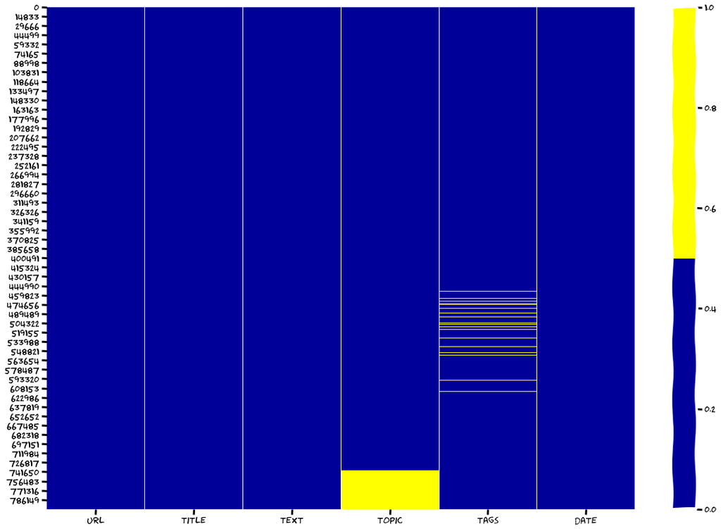

```python
def null_map(data):
    data_to_heat = data.isnull()
    data_to_heat.head()
    with plt.xkcd():
        plt.figure(figsize=(20,14))
        colors = ['#000099', '#ffff00']
        sns.heatmap(data_to_heat,cmap = sns.color_palette(colors));
null_map(data)
```

We can see that the columns have missing values, it is clear for topic and tag columns. But I'm sure, that in other columns we also have NANs. Let's look at some stats.

```python
text_nan_prop = data['text'].isnull().sum()/data['text'].shape[0]*100

print(f"text NAN proportion: {round(text_nan_prop,2)} %")
```

```
text NAN proportion: 0.0 %
```

```python
topic_nan_prop = data['topic'].isnull().sum()/data['topic'].shape[0]*100

print(f"topic NAN proportion: {round(topic_nan_prop,2)} %")
```

```
topic NAN proportion: 7.74 %
```

We have a lot of untitled news, it's ok, we will title it soon!

```python
tags_nan_prop = data['tags'].isnull().sum()/data['tags'].shape[0]*100
print(f"tags NAN proportion: {round(tags_nan_prop,2)} %")
```

```
tags NAN proportion: 3.4 %
```

```python
for col in data.columns:
  print(f'{col} NAN rate: {data[col].isnull().sum()}')
```

```
url NAN rate: 0
title NAN rate: 0
text NAN rate: 5
topic NAN rate: 62002
tags NAN rate: 27219
date NAN rate: 0
```

So, we have 5 missing cells in the Text columns, in preprocessing we'll get rid of it.

Let's look at our topic and tags distribution.

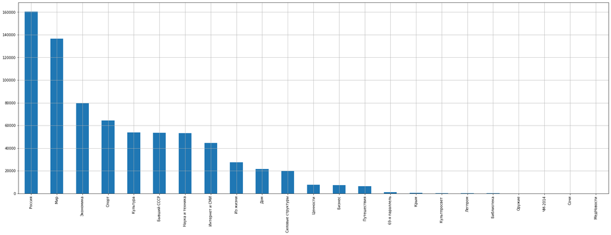

```python
data.topic.value_counts().plot(kind='bar',figsize=(30,10));
plt.grid()
```

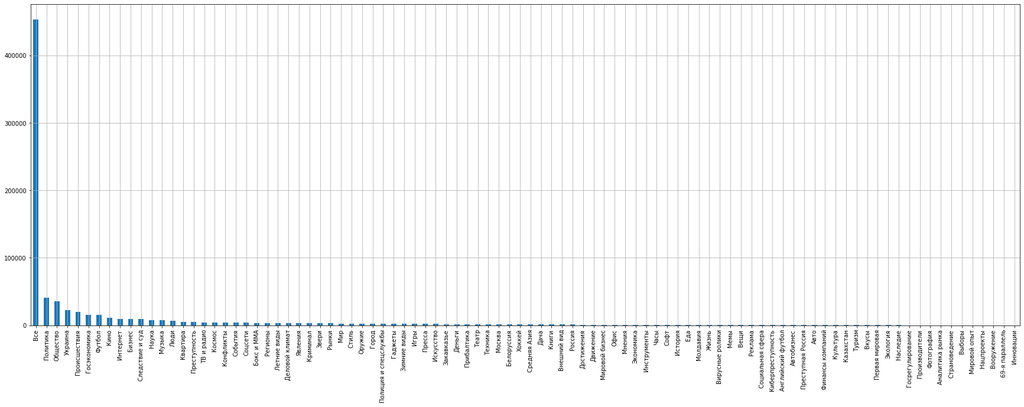

```python
data.tags.value_counts().plot(kind='bar',figsize=(30,10));
plt.grid()
```

We have a very big comon columns, let's get rid of it for a while.

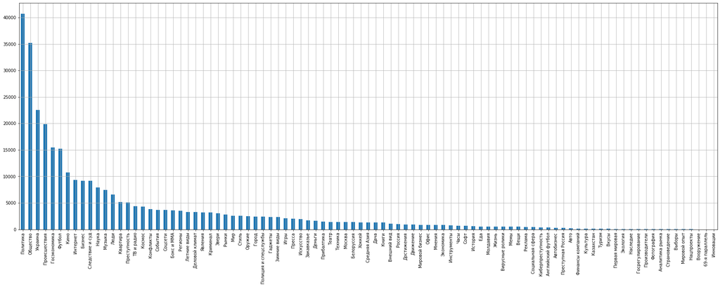

```python
data.tags.value_counts()[1:].plot(kind='bar',figsize=(30,10));
plt.grid()
```

So, our news mostly are about politics, government, accidents society, sports,arts, business and so on. I think, we'll have kind of 10-20 big and important topics in the end.

Let's look at the time ditribution.

```python
data.date = pd.to_datetime(data.date)
```

```python
data['year'] = data['date'].apply(lambda x: x.year)
```

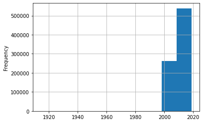

```python
data['year'].plot(kind='hist')
plt.grid()
```

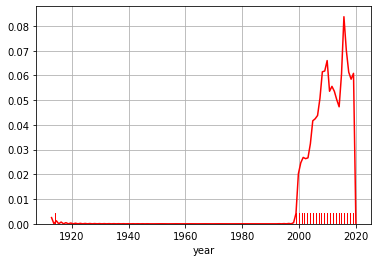

```python
sns.distplot(data['year'], hist=False, rug=True, color="r")
plt.grid()
```

So, we have anomalies from the past. I want to see it.

```python
data[data['year']<1995]
```

|  | url | title | text | topic | tags | date | year |
| --- | --- | --- | --- | --- | --- | --- | --- |
| 0 | https://lenta.ru/news/1914/09/16/hungarnn/ | 1914. Русские войска вступили в пределы Венгрии | Бои у Сопоцкина и Друскеник закончились отступ... | Библиотека | Первая мировая | 1914-09-16 | 1914 |
| 1 | https://lenta.ru/news/1914/09/16/lermontov/ | 1914. Празднование столетия М.Ю. Лермонтова от... | Министерство народного просвещения, в виду про... | Библиотека | Первая мировая | 1914-09-16 | 1914 |
| 2 | https://lenta.ru/news/1914/09/17/nesteroff/ | 1914. Das ist Nesteroff! | Штабс-капитан П. Н. Нестеров на днях, увидев в... | Библиотека | Первая мировая | 1914-09-17 | 1914 |
| 3 | https://lenta.ru/news/1914/09/17/bulldogn/ | 1914. Бульдог-гонец под Льежем | Фотограф-корреспондент Daily Mirror рассказыва... | Библиотека | Первая мировая | 1914-09-17 | 1914 |
| 4 | https://lenta.ru/news/1914/09/18/zver/ | 1914. Под Люблином пойман швабский зверь | Лица, приехавшие в Варшаву из Люблина, передаю... | Библиотека | Первая мировая | 1914-09-18 | 1914 |

Historical news, cool!

Let's look at the types of our columns, especially texts.

```python
data['is_lenta.ru'] = data['url'].apply(lambda x: x.find('lenta.ru')!=-1)
```

```python
(data['is_lenta.ru']==False).sum()
```

```
0
```

```python
data['is_news'] = data['url'].apply(lambda x: x.find('news')!=-1)
(data['is_lenta.ru']==False).sum()
```

```
0
```

```python
data['text_type'] = data['text'].apply(lambda x: type(x))
```

```python
data[data['text_type']!=str]
```

|  | url | title | text | topic | tags | date | year | is_lenta.ru | is_news | text_type |
| --- | --- | --- | --- | --- | --- | --- | --- | --- | --- | --- |
| 150785 | https://lenta.ru/news/2006/04/20/student1/ | Прокуратура не нашла национальной почвы в напа... | NaN | Россия | Все | 2006-04-20 | 2006 | True | True | <class 'float'> |
| 153075 | https://lenta.ru/news/2006/05/16/dagestan/ | При штурме дома в Кизилюрте ранены шестеро | NaN | Россия | Все | 2006-05-16 | 2006 | True | True | <class 'float'> |
| 153931 | https://lenta.ru/news/2006/05/24/fire/ | В Стамбуле горит багажное отделение аэропорта ... | NaN | Мир | Все | 2006-05-24 | 2006 | True | True | <class 'float'> |
| 154591 | https://lenta.ru/news/2006/05/31/an70/ | РФ вышла из российско-украинского проекта Ан-70 | NaN | Россия | Все | 2006-05-31 | 2006 | True | True | <class 'float'> |
| 582527 | https://lenta.ru/news/2016/02/23/aquarium/ | Гребенщиков заработал 10 тысяч рублей в омском... | NaN | Культура | Музыка | 2016-02-23 | 2016 | True | True | <class 'float'> |

```python
data['url_type'] = data['url'].apply(lambda x: type(x))
data[data['url_type']!=str]
```

|  | url | title | text | topic | tags | date | year | is_lenta.ru | is_news | text_type | url_type |
| --- | --- | --- | --- | --- | --- | --- | --- | --- | --- | --- | --- |

```python
data['title_type'] = data['title'].apply(lambda x: type(x))
data[data['title_type']!=str]
```

|  | url | title | text | topic | tags | date | year | is_lenta.ru | is_news | text_type | url_type | title_type |
| --- | --- | --- | --- | --- | --- | --- | --- | --- | --- | --- | --- | --- |

So,we have our 5 anomalies in texts yet, we will delete it during the preprocessing stage.

## Ok, we have our first analysis of the data. We've got some understanding of the topic distribution and cought some anomalies. In the next stage, we will clean it up and prepare for the further analysis. Let's go!